# Anthony Magazine VOL1

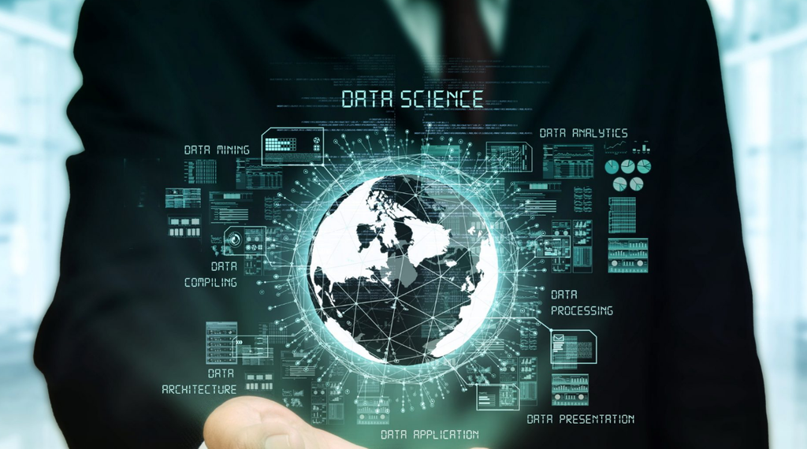

# APA ITU DATA SCIENCE

Data Science adalah suatu bidang interdisipliner yang berfokus pada pengolahan, analisis, dan interpretasi data untuk mendapatkan informasi yang berguna. Bidang ini melibatkan berbagai disiplin ilmu seperti matematika, statistika, komputer, dan domain spesifik lainnya.

Data Science mencakup berbagai tahap dalam pengolahan data, seperti pengumpulan data, pembersihan data, pengolahan data, visualisasi data, dan analisis data. Tujuan utama dari Data Science adalah untuk mendapatkan wawasan dan informasi yang dapat membantu pengambilan keputusan yang lebih baik.

Data Science dapat diterapkan dalam berbagai bidang seperti bisnis, ilmu sosial, kedokteran, teknik, dan masih banyak lagi. Beberapa contoh aplikasi Data Science adalah analisis pasar untuk menentukan strategi pemasaran yang tepat, analisis data medis untuk memprediksi risiko penyakit, dan analisis data cuaca untuk memprediksi cuaca di masa depan, dalam praktiknya, Data Science sering melibatkan penggunaan algoritma dan teknik machine learning untuk mengambil informasi yang tepat dari data. Teknik-teknik tersebut meliputi pengklasifikasian, regresi, klastering, dan lain sebagainya.

Pada era digital yang semakin maju, Data Science menjadi semakin penting dan banyak digunakan dalam berbagai industri dan bidang kehidupan.

# MANFAAT DATA SCIENCE

Data Science memiliki manfaat yang sangat banyak dalam berbagai bidang kehidupan, di antaranya:

Pengambilan Keputusan yang Lebih Baik: Dengan Data Science, kita dapat menganalisis data dengan lebih akurat dan efisien, sehingga dapat menghasilkan informasi yang berguna untuk membantu pengambilan keputusan yang lebih baik.

Meningkatkan Efisiensi: Data Science dapat membantu kita untuk mempercepat proses bisnis dan mengurangi biaya yang terkait dengan operasional. Dengan menganalisis data, kita dapat menemukan area yang perlu dioptimalkan untuk meningkatkan efisiensi bisnis.

Mengidentifikasi Pola dan Tren: Data Science memungkinkan kita untuk mengidentifikasi pola dan tren yang muncul dalam data. Dengan menganalisis tren tersebut, kita dapat membuat keputusan yang lebih cerdas dan mengantisipasi perubahan yang akan datang.

Memahami Pelanggan: Data Science dapat membantu kita memahami pelanggan dengan lebih baik, dari perilaku pembelian hingga preferensi produk. Dengan memahami pelanggan, kita dapat mengembangkan strategi pemasaran yang lebih efektif dan meningkatkan loyalitas pelanggan.

Meningkatkan Kualitas Produk dan Layanan: Dengan menganalisis data, kita dapat mengidentifikasi kelemahan dan kekuatan dalam produk dan layanan yang kita tawarkan. Hal ini dapat membantu kita meningkatkan kualitas produk dan layanan yang kita berikan kepada pelanggan.

Meningkatkan Keamanan: Data Science dapat membantu kita mengidentifikasi ancaman keamanan, seperti serangan siber dan fraud. Dengan menganalisis data, kita dapat membangun model prediktif untuk memprediksi risiko dan mencegah ancaman keamanan tersebut.

Mendorong Inovasi: Data Science dapat membantu kita menemukan peluang baru dan membuat inovasi yang dapat meningkatkan bisnis dan produk kita.

Dalam kesimpulannya, Data Science dapat membantu kita untuk mengambil keputusan yang lebih baik, meningkatkan efisiensi bisnis, memahami pelanggan, meningkatkan kualitas produk dan layanan, meningkatkan keamanan, dan mendorong inovasi. Oleh karena itu, Data Science menjadi semakin penting di era digital yang semakin maju.

# DATA SCIENCE & INDUSTRI

Data Science dapat diterapkan di berbagai industri dan bidang, di antaranya:

Bisnis dan Keuangan: Data Science dapat membantu perusahaan untuk meningkatkan efisiensi bisnis, memahami pelanggan, mengidentifikasi peluang bisnis baru, dan meningkatkan keuntungan. Contohnya, penggunaan analisis data untuk membuat model prediktif untuk memprediksi tren pasar dan memperkirakan kinerja keuangan.

Kedokteran dan Kesehatan: Data Science dapat membantu dokter dan peneliti untuk membuat prediksi penyakit, mengembangkan pengobatan yang lebih efektif, dan meningkatkan efisiensi sistem kesehatan. Contohnya, penggunaan analisis data untuk mengidentifikasi faktor risiko yang mempengaruhi kesehatan dan membuat model prediktif untuk memprediksi risiko penyakit.

Pendidikan: Data Science dapat membantu untuk meningkatkan efektivitas pembelajaran dan memberikan pendidikan yang lebih personal. Contohnya, penggunaan analisis data untuk mengidentifikasi pola dalam pembelajaran dan memberikan saran pembelajaran yang lebih cocok untuk setiap siswa.

Teknologi: Data Science merupakan salah satu bagian penting dalam pengembangan teknologi terkini seperti Artificial Intelligence (AI), Machine Learning, dan Big Data. Contohnya, penggunaan analisis data untuk mengembangkan aplikasi cerdas dan sistem otomatisasi.

Transportasi dan Logistik: Data Science dapat membantu untuk meningkatkan efisiensi dan produktivitas di sektor transportasi dan logistik. Contohnya, penggunaan analisis data untuk mengoptimalkan rute dan jadwal pengiriman barang, dan membuat sistem prediktif untuk memprediksi permintaan dan stok barang.

E-commerce: Data Science dapat membantu perusahaan e-commerce untuk meningkatkan pengalaman pelanggan dan meningkatkan penjualan. Contohnya, penggunaan analisis data untuk memahami perilaku belanja pelanggan dan memberikan rekomendasi produk yang lebih tepat.

Ilmu Sosial: Data Science dapat membantu peneliti untuk memahami perilaku manusia dan mengembangkan model prediktif untuk memprediksi perilaku sosial. Contohnya, penggunaan analisis data untuk memprediksi perilaku pemilih dalam pemilihan umum.

Itulah beberapa contoh industri dan bidang yang dapat menerapkan Data Science. Namun, sebenarnya hampir semua industri dan bidang dapat mengambil manfaat dari Data Science untuk meningkatkan efisiensi, meningkatkan kualitas produk dan layanan, dan membuat keputusan yang lebih baik.

Apabila anda tertarik untuk sharing terkait **Data Science & AI (Artificial Intelligence)** dapat menghubungi saya di [Linkedin Anthony](https://www.linkedin.com/in/rinoanthoy/) & silahkan kunjungi [Github Anthony](https://github.com/AnthonySSSSS) untuk melihat *project* lainnya.